# Modelling the Stock-Recruitment relationship

Todor Dimitrov

8/28/2019

## Introduction

Estimating and modeling the stock-recruitment relationship has been a central issue in fishery dynamics. Over the years, a wide variety of suggestions and solutions have appeared to fit and estimate critical parameters. These span from drawing recruitment curves by eye to a strictly statistical procedure of curve fitting [^1]. While each approach has its own validity and use, Bayesian methodology and state-space modelling have become the prominent focus of more recent literature [^2]. Through this paper, we aim to highlight the benefits of combining both methodologies with regards to fishery population dynamics.

### State-space Framework

As models have developed over time, focus has shifted from simply fitting a curve to assuring that key sources of error have been considered and included [^3]. In particular, the importance of both observation error and process variability has become increasingly recognized in within fishery literature [^4]. Observation error, as one would expect, results in variability in the methods used to obtain population growth. Source of observation error include sampling error as well as human error and harsh environmental conditions. On the other hand, process error models the random error in the state equation being used [^5].A state-space model aims to separate the two sources of error to better simulate and analyze them.

#### Basic State-space model

Let $x_t$ be a population state at time $t$ and $y_t$ represent the observation made. The state-space model is therefore as follows:

$x_t = f(x_{t-1}) + \epsilon_t$  
$y_t = g(x_t) + \omega_t$

Through this framework, we are able of separating the two sources of error: $\epsilon_t$ (Process Error) and $\omega_t$ (Observation error). The first equation is our process equation while the second is our observation equation. With some minor alterations, this framework will be the guiding principle behind our stock-recruitment model. In particular, we will focus on the log densities of the states ($x_t = ln(n_t)$). This, with the assumptions that $\epsilon_t \sim N(0, \sigma^2)$ and $\omega_t \sim N(0, \tau^2)$ will give us a lognormal distribution for both the process and observation models. In terms of functions we will use the Beverton-Holt equation, a population model which takes in the spawner count, productivity (slope at origin), and capacity of the population. There are many other choices, such as the Ricker model, but for our study we decided to focus on the Beverton-Holt function.

$f(S) = \frac{S}{\frac{1}{p} + \frac{S}{c}}$

$g(x) = x$

Here $p$ represents productivity, $c$ is capacity, and $S$ is the spawner count. Using this basic framework, we can accurately incorporate both observation and process error into our model.

## Models

1. Simple model only using Beverton-Holt equation.
2. Bayesian state space model.
3. Modeling with varied process errors.

### Data Generation

First, to illustrate and be able to test the validity of our models, we needed a testing data set. Using the state space model outlined in the previous section, we were able to simulate 100 years of population data. We used an initial state of 1000 individuals in the population with a capacity of 1200 and a productivity of 2.5. We assumed that the observation error was known ($\omega_t = 0.15$) as well as process error ($\epsilon_t = 0.1$). Furthermore, to avoid clustering of data we added a known harvest rate ($HR$), ranging from 0 to 0.63. We also added a percentage of hatchery fish which entered the wild ($Phas$). This value ranged from 0 to 0.9.

Process Model:

```r
bevholt = function(S, prod, cap) {
  S/(1/prod+S/cap)
}

set.seed(123)
N <- 100
Phas <- sample(rep(seq(0, .9, .1), rep(N/10,10)))
HR <- sample(rep(seq(0, .63, .07), rep(N/10,10)))
S <- numeric(N)
S[1] <- 1000
cap <- 1200
prod <- 2.5
for (i in 1:(N-1)){
  S[i+1] <- rlnorm(1, log(bevholt(S[i], prod, cap)*(1-HR[i])/(1-Phas[i])), .1)
}
```

Observation Model:

```r
Sobs <- numeric(N)
for (i in 1:N) {
  Sobs[i] <- rlnorm(1, log(S[i]), .15)
}
```

The following plots are that of the ‘actual’ data generated and the observed data:

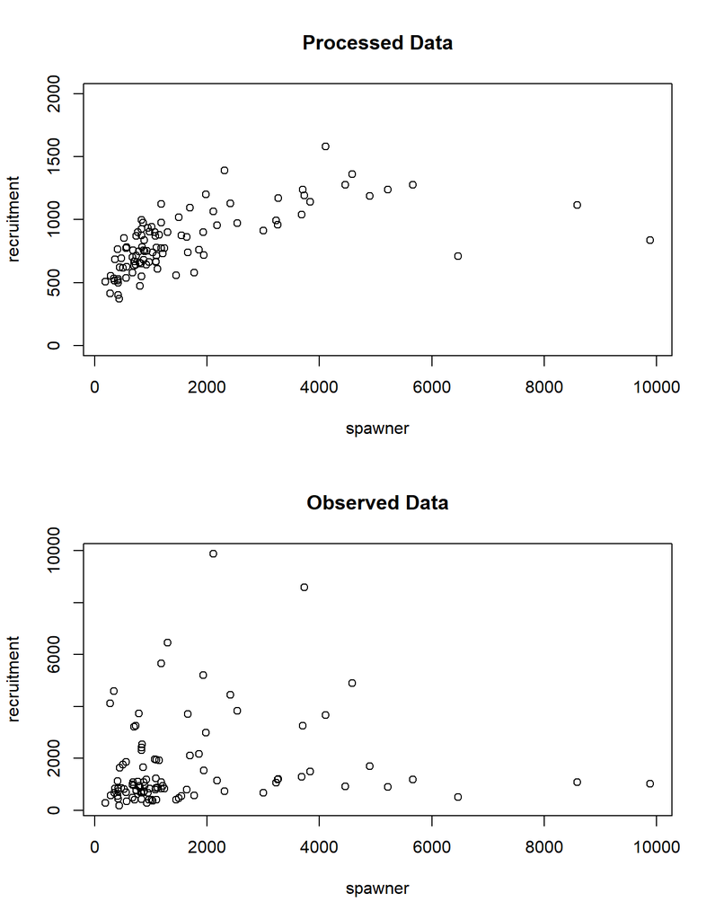

```r
par(mfrow=c(2,1))
plot(Sobs[-100],Sobs[-1]*(1-Phas[-100])/(1-HR[-100]), xlab="spawner", ylab="recruitment", main="Processed Data", ylim = c(0,2000))
plot(Sobs[-100],Sobs[-1], xlab="spawner", ylab="recruitment", main="Observed Data")
```

### Simple Model (Non State-based)

Part of creating a accurate Bayesian stock model is careful consideration of the priors. For some parameters guidance can be found in past literature [^6]. In our case, since we simulated our data, we are going to assume that the following are reasonable priors:

$pro \sim lognormal(log(3), 0.01)$  
$cap \sim lognormal(log(15000), 0.001))$  
$\tau \sim gamma(0.001, 0.001)$

Here, $\tau = \frac{1}{\sigma^2}$  
Now, using JAGS, we can create our simple model. Here, we attempt to model using only the observed data.

```r
simple.bug <- '
model {
  for (i in 1:(Nyears-1)) {
    R[i] ~ dlnorm(log(mu[i]), tau)
    mu[i] <- S[i]/(1/prod + S[i]/cap)
  }

  prod ~ dlnorm(log(3), 0.01)
  cap ~ dlnorm(log(15000), 0.001)
  tau ~ dgamma(0.001, 0.001)
}
'
```

We are then able to run the model with initial values of prod = 1 and cap = 600. These models usually account for given harvest rates and hatchery proportions. Because of this we transformed the data before running the model.

```r
initValFunc <- function() {
  list(prod=1, cap=600)
}
jagsDat <- list(S=Sobs[-100], R=Sobs[-1]*(1-Phas[-100])/(1-HR[-100]), Nyears=N)
m.simple <- jags.model(textConnection(simple.bug), data=jagsDat, initValFunc, n.chains=3)
s.simple <- jags.samples(m.simple,n.iter=10000,variable.names=c("prod","cap", "tau"))
prodLi <- s.simple$prod
capLi <- s.simple$cap
sigmaLi <- sqrt(1/s.simple$tau)
U <- 1-1/sqrt(prodLi)
median(prodLi)
```

```
## [1] 2.662213
```

```r
median(capLi)
```

```
## [1] 1147.69
```

This model generates a reasonable results. By sampling from the posterior distribution of the parameters, we can see the median of productivity and capacity are around the set values we used to generate the data. To get a sense of the wide range of plausible curves, we can plot multiple Beverton-Holt curves using sample capacities and productivity. The 1:1 reference line was plotted as well.

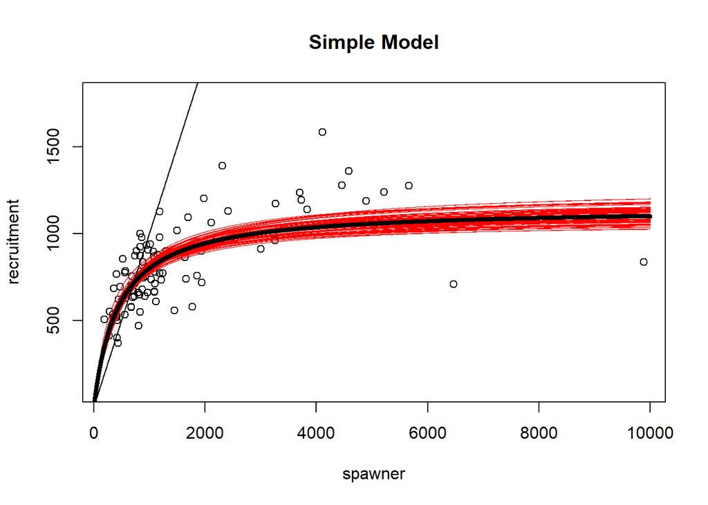

```r
par(mfrow = c(1,1))
plot(Sobs[-100],Sobs[-1]*(1-Phas[-100])/(1-HR[-100]), ylim = c(100,1800), xlab="spawner", ylab="recruitment", main="Simple Model")
SS <- 0:10000
Ndraws <- 100
for (i in 1:Ndraws) {
  draw <- sample(1:length(prodLi), 1)
  lines(SS, bevholt(SS, prodLi[draw], capLi[draw]), type = "l", col = 2, lwd = .5)
}
lines(SS, bevholt(SS, median(prodLi), median(capLi)), type = "l", col = 1, lwd = 4)
lines(SS, SS)
```

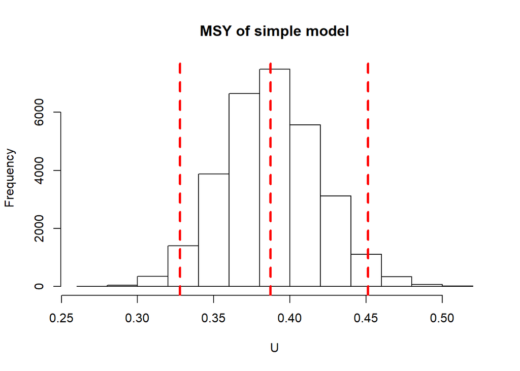

```r
hist(U, main = "MSY of simple model")
abline(v = quantile(U,prob=c(0.025,0.5,0.975)), col="red", lwd=3, lty=2)
```

```r
quantile(prodLi,prob=c(0.025,0.5,0.975))
```

```
##     2.5%      50%    97.5%
## 2.213062 2.662213 3.318987
```

A similar procedure can be done for productivity and capacity.

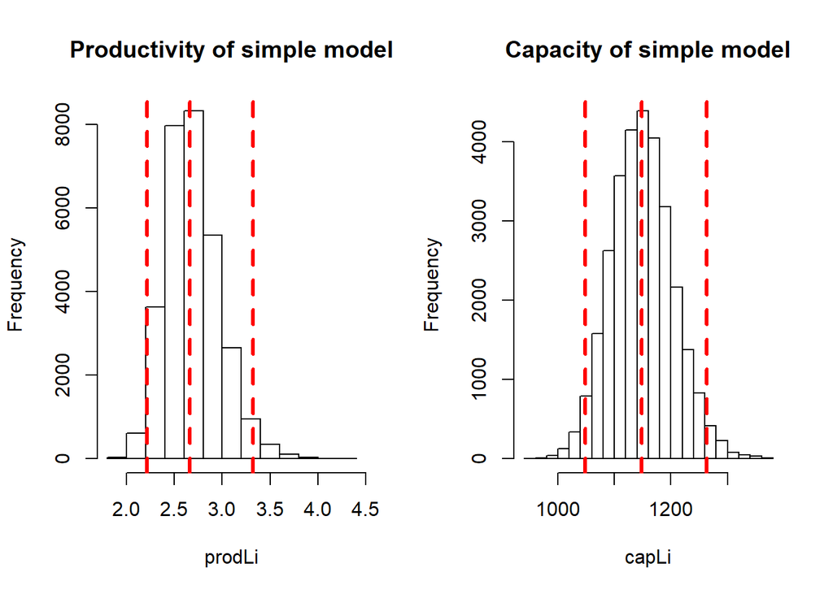

Ultimately, what we see is that the simple model does a relatively accurate job of bounding the parameters as well as estimating values such as MSY. However, once again, this model was under ideal conditions (large quantities of data, relatively small error) and does not incorporate or take into account the different forms of error which occur from generating these observations.

### State-based Model

Now, we will look at a state-based model under the same conditions as the simple model. We are using the same generated data and priors as above. However, now, in our model, we will explicitly model the process and the observation. Here, we will assume that observation error has been measured and is known.

```r
state.bug <- '
model {
  S[1] ~ dlnorm(0,0.0001)
  for(i in 1:(Nyears-1)) {
    S[i+1] ~ dlnorm(log((S[i]/(1/prod + S[i]/cap))*(1/(1-Phas[i]))*(1-HR[i])), tau)
  }

  for (i in 1:Nyears) {
    Sobs[i] ~ dlnorm(log(S[i]),1/(.15*.15))
  }

  prod ~ dlnorm(log(3), 0.01)
  cap ~ dlnorm(log(15000), 0.001)
  tau ~ dgamma(0.001, 0.001)
}
'
```

Using a similar process as above we can run the model with initial values of prod = 1 and cap = 600.

```r
jagsDat <- list(Sobs=Sobs, Nyears=N, Phas=Phas, HR=HR)
m.state <- jags.model(textConnection(state.bug), data=jagsDat, initValFunc, n.chains=3, n.adapt=5000)
s.state <- jags.samples(m.state,n.iter=10000,variable.names=c("prod","cap", "tau", "S"))
prodLi <- s.state$prod
capLi <- s.state$cap
sigmaLi <- sqrt(1/s.state$tau)
U <- 1-1/sqrt(prodLi)
median(prodLi)
```

```
## [1] 2.545583
```

```r
median(capLi)
```

```
## [1] 1168.125
```

A sample of parameters were used to plot Beverton-Holt curves to see the spread.

[figure not shown]

A summary of the the parameter posterior distributions as well as MSY can be quickly calculated. Once again, the 95% credible intervals as well as the medians of each distributions are plotted. First the calculated values.

[figure not shown]

```
##     2.5%      50%    97.5%
## 2.196515 2.545583 2.997451
```

The parameters:

[figure not shown]

The credible intervals for the parameters are a bit tighter around the true values, however, under these ideal conditions, both models do a accurate job of estimating the parameter values.

### Varying Process error

We will now take a look at how varying the process error effects each models accuracy for predicting parameters. To perform this, we generate data using a similar process as seen above, simply varying the used process error from $0.1$ to $0.7$. In fisheries modeling, this source of error could be caused from poor knowledge of or lack of sufficient information about the processes at hand. The following graphs and table summarize the results from varying process error

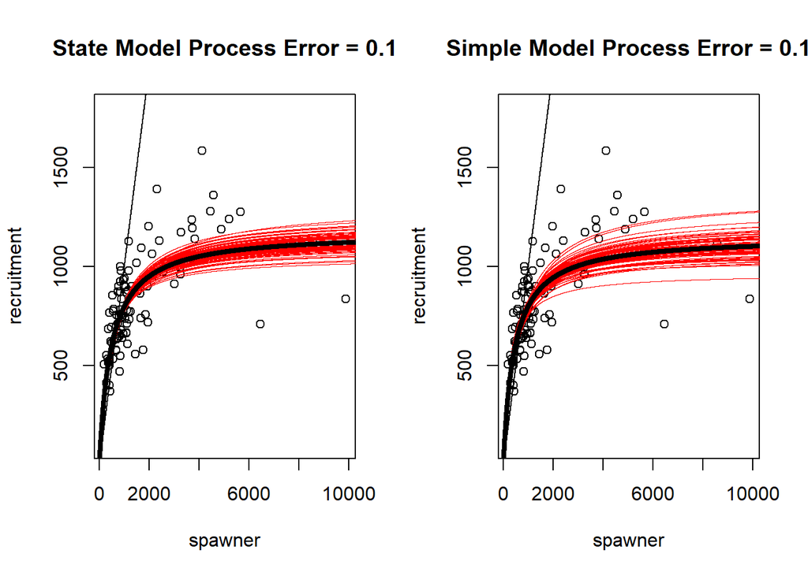

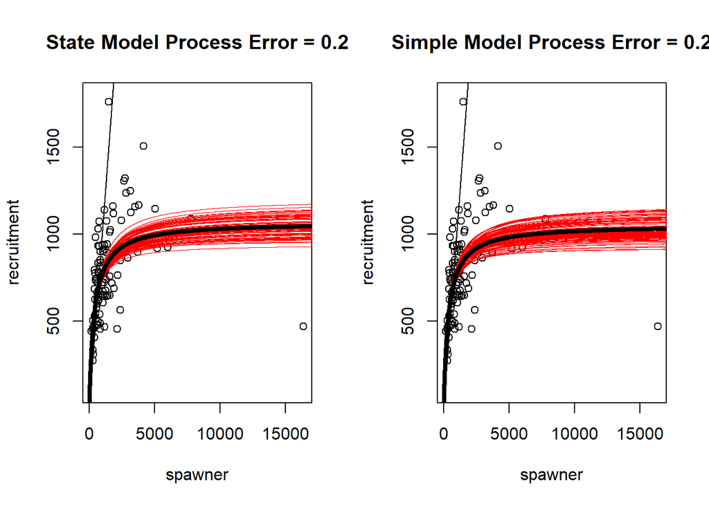

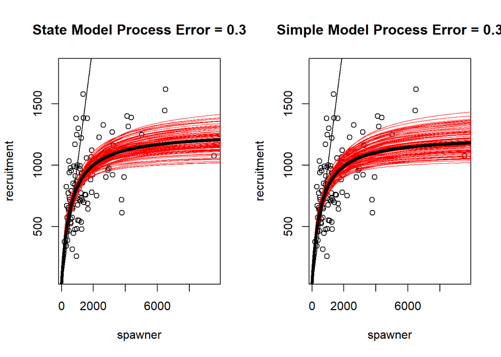

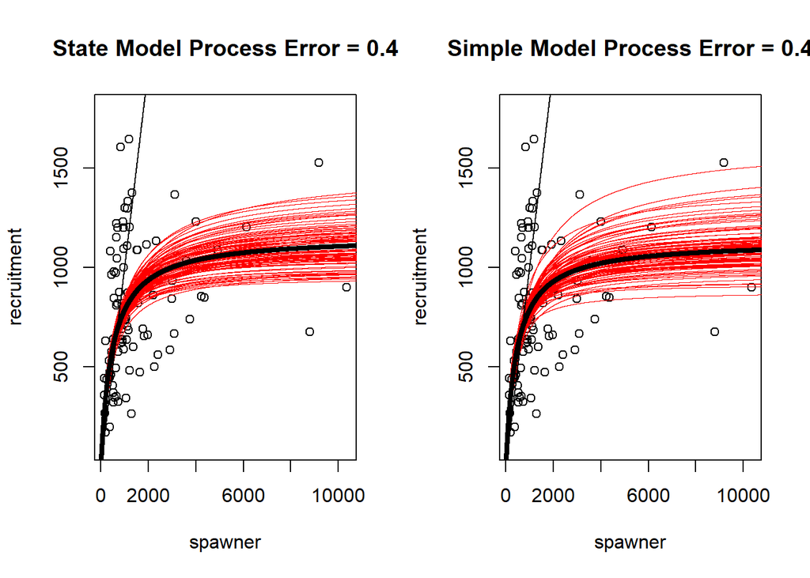

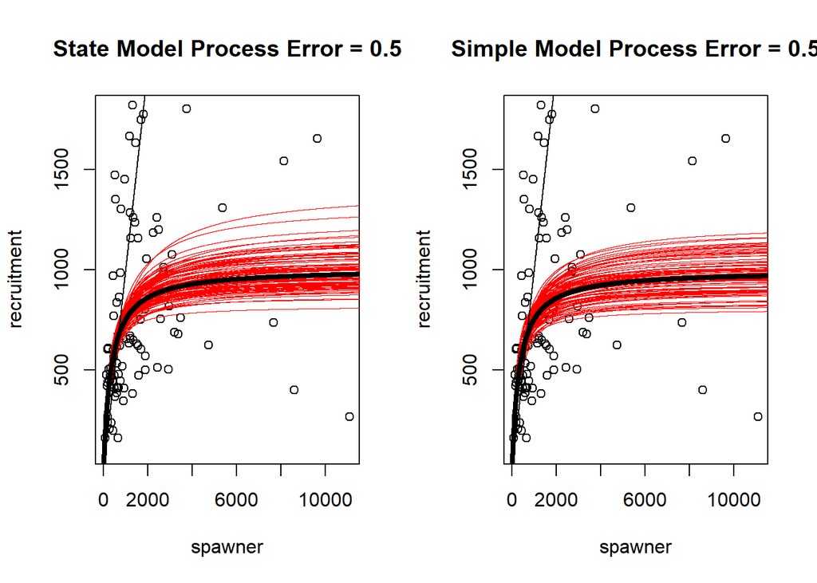

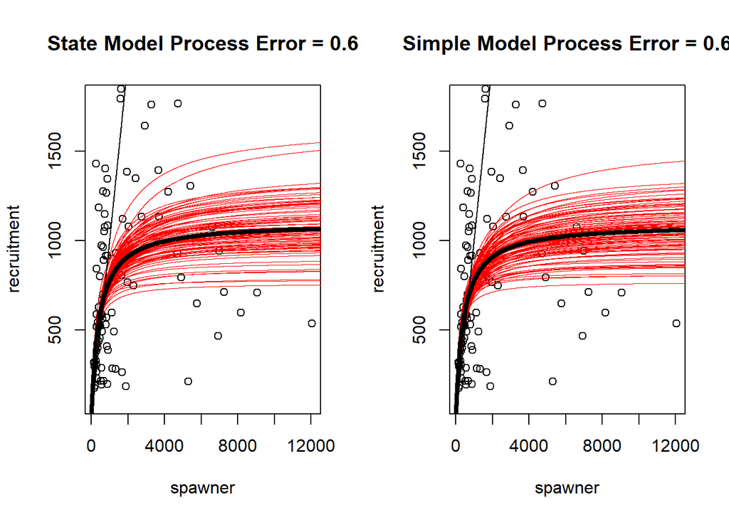

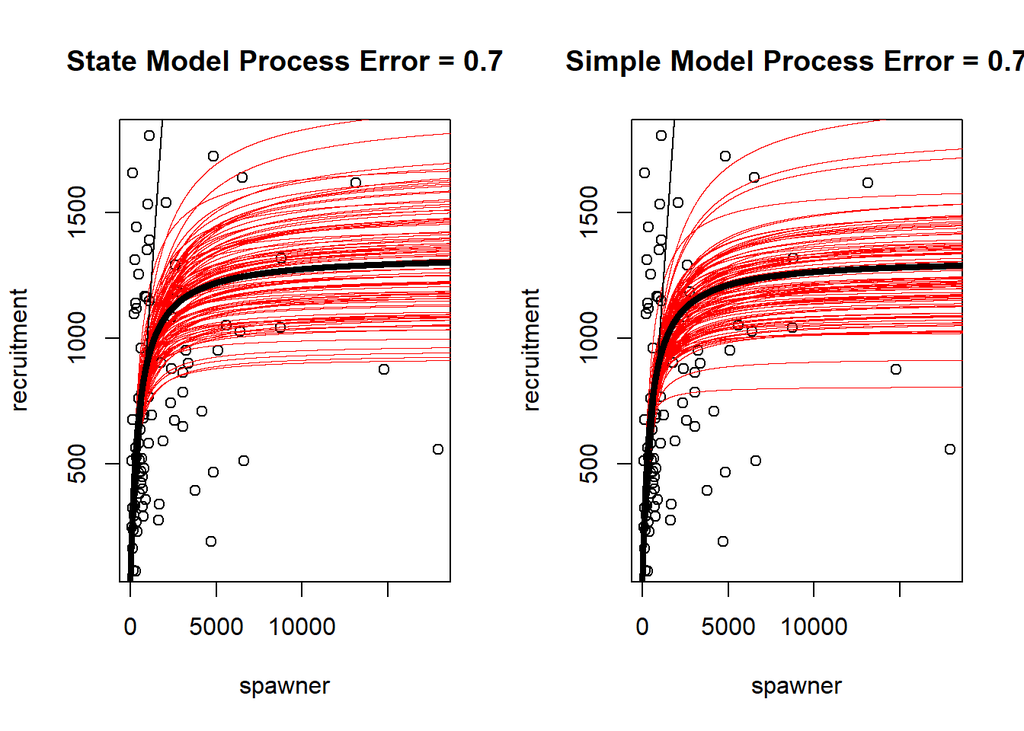

State Model

|  | 1 | 2 | 3 | 4 | 5 | 6 | 7 |
| --- | --- | --- | --- | --- | --- | --- | --- |
| Prod Median | 2.5248968 | 2.8173945 | 2.3675891 | 2.4826617 | 3.0315068 | 2.6791627 | 2.8819654 |
| Cap Median | 1172.2732069 | 1068.3663588 | 1271.5395085 | 1156.4543701 | 1005.0888590 | 1098.8331094 | 1332.1122749 |
| Prod sd | 0.2164862 | 0.4034412 | 0.4176152 | 0.5582866 | 0.7971582 | 0.8002395 | 1.2290426 |
| Cap sd | 50.2056655 | 63.4857336 | 110.9649773 | 119.2697399 | 101.9943337 | 148.5730302 | 194.2478984 |
| Estimated Process error | 0.1003589 | 0.2122232 | 0.2967433 | 0.4065026 | 0.4913776 | 0.6242934 | 0.7388728 |

Simple Model

|  | 1 | 2 | 3 | 4 | 5 | 6 | 7 |
| --- | --- | --- | --- | --- | --- | --- | --- |
| Prod Median | 2.6582945 | 2.9518940 | 2.4906132 | 2.6221094 | 3.1430513 | 2.7228187 | 2.996152 |
| Cap Median | 1148.4975668 | 1051.4362358 | 1240.4517654 | 1130.7301638 | 994.9216221 | 1091.7585808 | 1317.453000 |
| Prod sd | 0.2864288 | 0.4599075 | 0.4745998 | 0.5877206 | 0.8017104 | 0.8112392 | 1.059359 |
| Cap sd | 54.7481605 | 63.2508067 | 108.2220036 | 114.4514917 | 98.8114507 | 144.0587530 | 188.897766 |

From the tables above we can see that both models struggle to fit the curves when process error gets large. This can also be seen in the graphs by the larger spread of the drawn curves. However, the clear advantage of the state-based approach is that it does an accurate job of modeling the process error. In other words, the state-based model is more informative.

[^1]: Walters and Ludwig 1981
[^2]: Clark and Bjørnstad 2004
[^3]: Walters and Ludwig 1981
[^4]: Ahrestani, Hebblewhite, and Post 2013
[^5]: Miller and Meyer 1999
[^6]: Miller and Meyer 1999
[^7]: Clark and Bjørnstad 2004